# STAT 707 Homework 1

# Exercise 6.28

You have been asked to evaluate two alternative models for predicting the number of active physicians $(Y)$ in a CDI. Proposed model I includes as predictor variables total population $(X_1)$, land area $(X_2)$, and total personal income $(X_3)$. Proposed model II includes as predictor variables population density ($X_1$, the total population divided by land area), percent of population greater than 64 years old $(X_2)$, and total personal income $(X_3)$

```r
CD1 <- read.csv("CDI_Data.csv", header = FALSE)
```

```r
names(CD1) <- c("ID", "county", "state","land_area","total_pop","percent_pop_18_34","percent_pop_65","num_physicians","n_hos_beds","total_crimes","percent_hs_grads","percent_bach","percent_pov","percent_unemp","per_capita","total_income","geographic_region" )
```

```r
CDI <- CD1
```

```r
library(ggplot2)
#stem(CDI$land_area,scale = 10)
```

## b. Obtain the scatter plot matrix and the correlation matrix for each proposed model. Summarize the information provided.

```r
library(GGally)
```

We will first begin with a combination of a scatter plot, density plot and the correlation values of the variables.

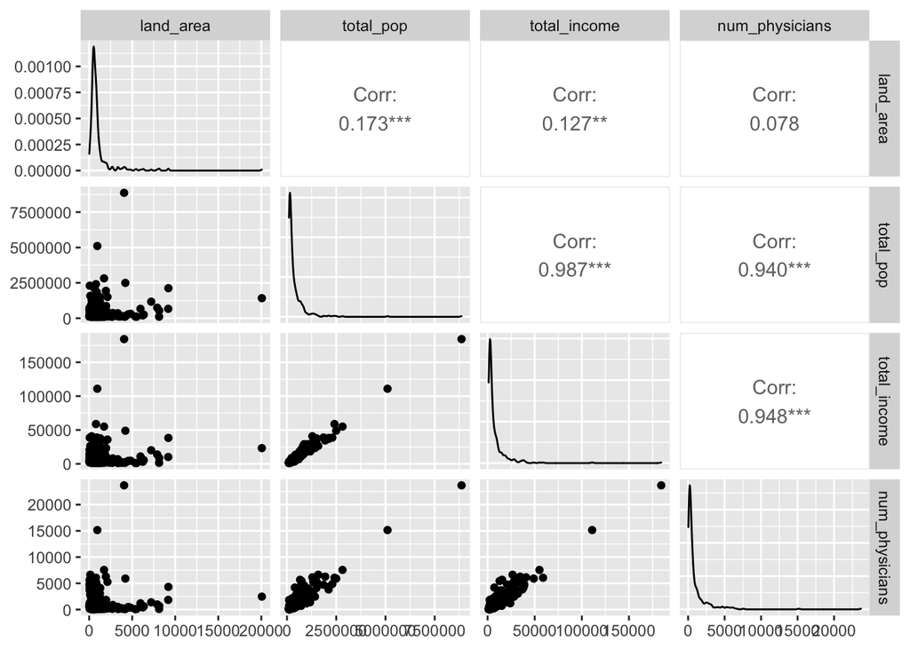

```r
ggpairs(CDI, columns = c(4,5,16, 8))
```

We then look at a more visual correlation plot, detailing that the number of physicians, total personal income and the total population of the county are highly correlated with each other.

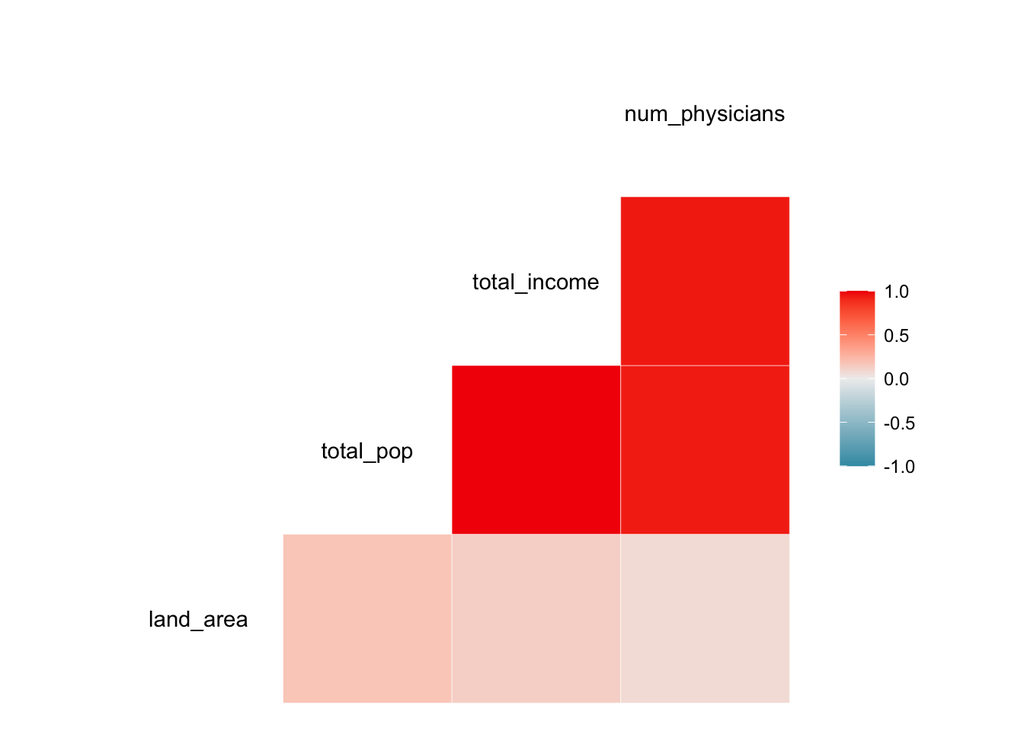

```r
ggcorr(data = CDI[,c(4,5,16, 8)], method = c("everything","pearson"))
```

### We will now look at the second model. A new variable “pop_density” will need to be created, to represent the total population divided by the land area.

```r
CDI["pop_density"] <- CDI$total_pop/CDI$land_area
```

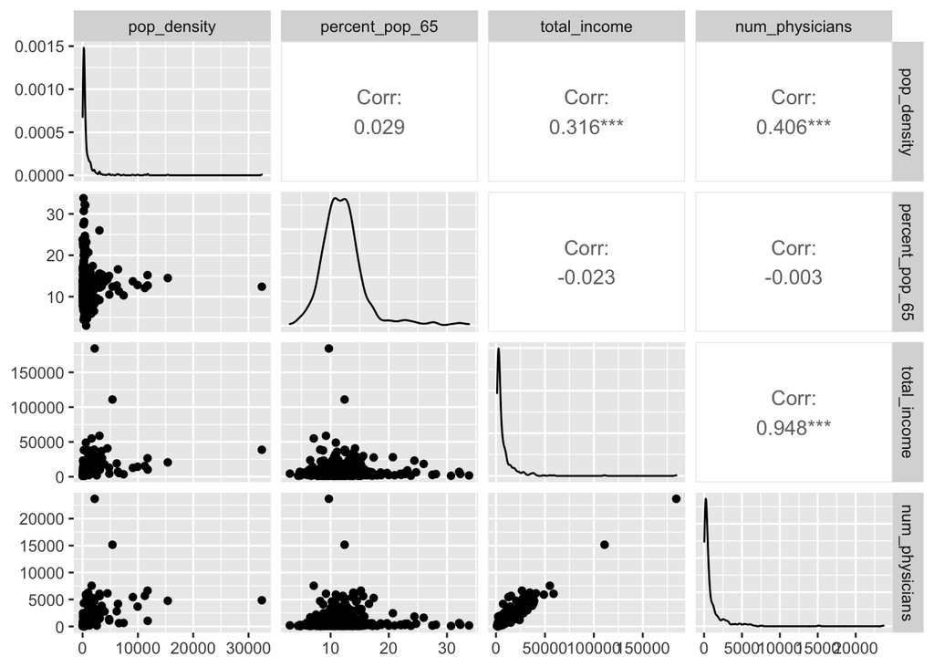

```r
ggpairs(data = CDI[,c(18,7,16,8)])
```

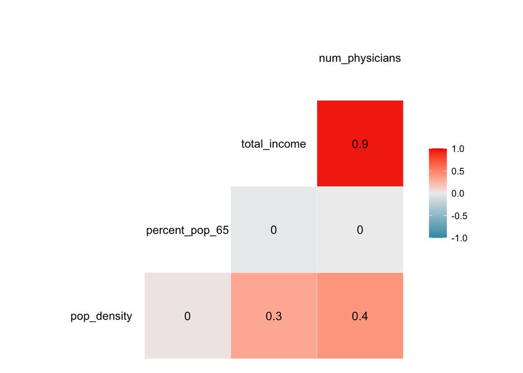

```r
ggcorr(data = CDI[,c(18,7,16,8)], method = c("everything","pearson"), label = TRUE)
```

We see that most of the variables are skewed to the right, with the “percent of population 65 or older”, being the only variable who appears to approach a normal distribution. Two pairs, “percent_pop_65” with “total_income” and “percent_pop_65” with “num_physicians” have low negative correlation values. The number of physicians again, appears to be highly correlated with total income.

## c. For each proposed model, fit the first-order regression model (6.5) with three predictor variables.

#### For both models, we will fit the regression:

$$Y_i = \beta_0 + \beta_{1}X_{i1}+\beta_{2}X_{i2}+\beta_3X_{i3} + \epsilon_i$$

#### using our indicated predicted variables.

### Model 1

```r
model_1 <- glm(num_physicians ~ total_pop + land_area + total_income, data = CDI)
```

$$\hat{Y_1} = -13.3162 + 0.000836618X_1-0.065523X_2+0.094132X_3$$

### Model 2

```r
model_2 <- glm(num_physicians ~ pop_density + percent_pop_65 + total_income, data = CDI)
```

$$\hat{Y_2} = -170.574 + 0.0961589X_1+6.33984X_2+0.126566X_3$$

## d. Calculate $R^2$ for each model. Is one model clearly preferable in terms of this measure?

```r
model_1_R2 <- with(summary(model_1), 1 - deviance/null.deviance)
model_2_R2 <- with(summary(model_2), 1 - deviance/null.deviance)
```

The coefficient of multiple determination, $R^2$ for model 1 is equal to 0.9026432, while the $R^2$ for model 2 is equal to 0.9117491. You can’t determine which model is more preferable in terms of their $R^2$, other tests of normality should be conducted.

## e. For each model, obtain the residuals and plot them against $\hat{Y}$, each of the three predictor varaibles, and each of the two-factor interaction terms.$

We will first obtain the residuals of both models, and concatenate them to our CDI data frame.

```r
CDI["model_1_resid"] <- residuals(model_1)
CDI["model_2_resid"] <- residuals(model_2)
```

### Model 1 diagnostics

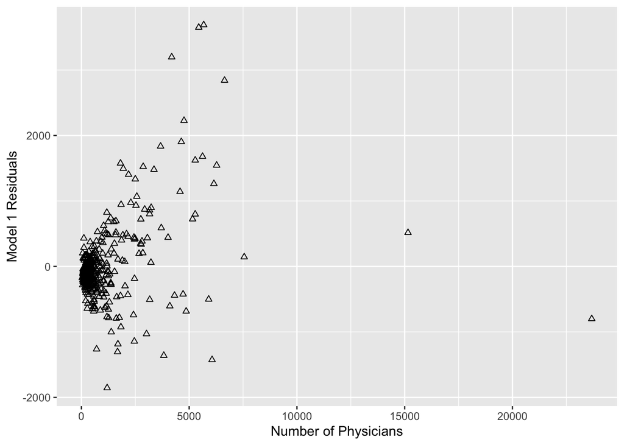

```r
ggplot(data = CDI, mapping = aes(x = num_physicians, y = model_1_resid)) + geom_point(shape = 24) + labs(y = "Model 1 Residuals", x = "Number of Physicians")
```

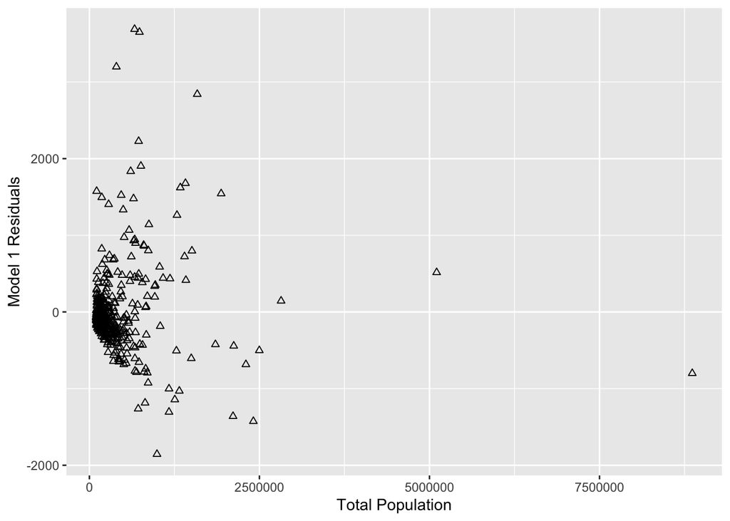

```r
ggplot(data = CDI, mapping = aes(x = total_pop, y = model_1_resid)) + geom_point(shape = 24) + labs(y = "Model 1 Residuals", x = "Total Population")
```

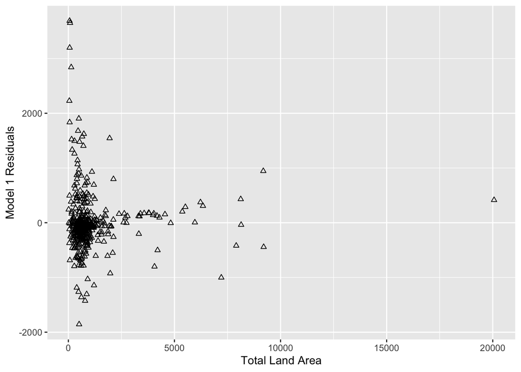

```r
ggplot(data = CDI, mapping = aes(x = land_area, y = model_1_resid)) + geom_point(shape = 24) + labs(y = "Model 1 Residuals", x = "Total Land Area")
```

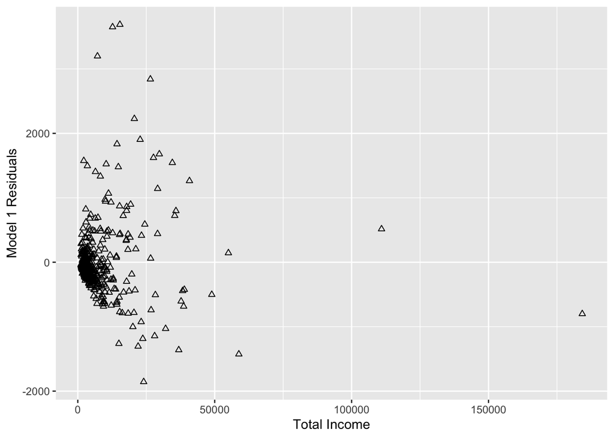

```r
ggplot(data = CDI, mapping = aes(x = total_income, y = model_1_resid)) + geom_point(shape = 24) + labs(y = "Model 1 Residuals", x = "Total Income")
```

### Model 2 Diagnostics

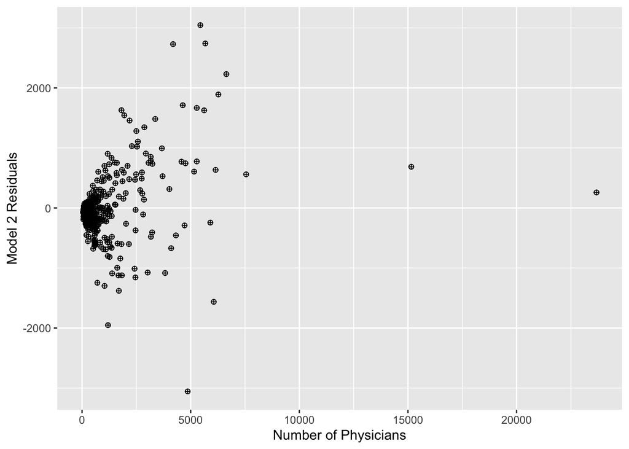

```r
ggplot(data = CDI, mapping = aes(x = num_physicians, y = model_2_resid)) + geom_point(shape = 10) + labs(y = "Model 2 Residuals", x = "Number of Physicians")
```

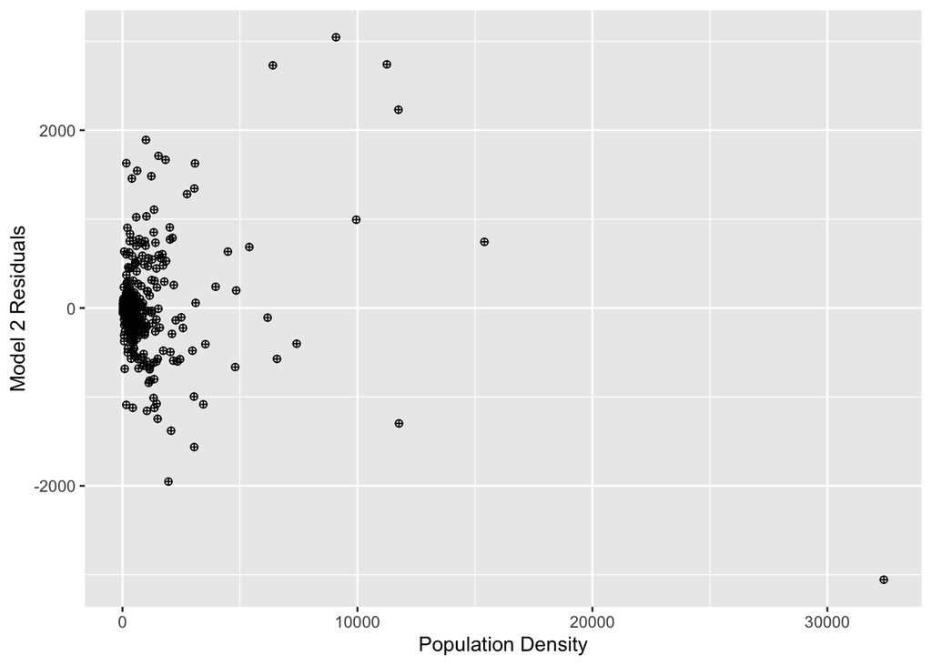

```r
ggplot(data = CDI, mapping = aes(x = pop_density, y = model_2_resid)) + geom_point(shape = 10) + labs(y = "Model 2 Residuals", x = "Population Density")
```